# MEML_Final_P1_Soln

**Machine Learning for Mechanical Engineering**  
**Final Exam, Part 1 - Solution**  
**Thursday, 06/09/2023, 07:00~08:30 PM**

TA: Jaejun Lee  
Instructor: Prof. Seungchul Lee  
http://iai.postech.ac.kr/  
Industrial AI Lab at POSTECH

- For your code, txt and .ipynb file will be graded.
- Please write your NAME and student ID on your .ipynb files. ex) Jaejun_Lee_20212781_FINAL.ipynb

# Problem 1 [10pt]

1) [2pt] (Choose correct answers) Jaehyun just trained a decision tree for a digit recognition. He notices an extremely low training error, but an abnormally large test error. He also notices that an SVM with a linear kernel performs much better than his tree. Whar could be the cause of his problem? (2 choices)

$\quad$ a. Decision tree is too deep

$\quad$ b. Decision tree is overfitting

$\quad$ c. Learning rate too high

$\quad$ d. There is too much training data

2) [2pt] (Choose correct answers) Gyuri has now switched to multilayer neural networks and notices that the training error is going down and converges to a local minimum. Then when he tests on the new data, the test error is abnormally high. What is probably going wrong and what do you recommend him to do? (3 choices)

$\quad$ a.The training data size is not large enough. Collect a larger training data and retrain it.

$\quad$ b. Play with learning rate and add regularization term to the objective function.

$\quad$ c. Use a different initialization and train the network several times. Use the average of predictions from all nets to predict test data.

$\quad$ d. Use the same training data but add two more hidden layers.

3) [2pt] (Choose all the correct answers) Minjung is tyring to solve the XOR problem using a multilayer perceptron (MLP). However, as he trains the MLP model, the results vary at every iteration. The results are correct in some iterations, and the results are wrong at the other iterations. What is probably going wrong and what do you recommend him to do?

$\quad$ a. The training data points are not large enough. Collect a larger training data points and re-train it.

$\quad$ b. The number of perceptron layers is too large. Remove the perceptron layers and re-train it.

$\quad$ c. The number of perceptron layers is too small. Add more the perceptron layers and re-train it.

$\quad$ d. Learning rate is too high. Reduce learning rate and re-train it.

4) True or false for the following questions. (Correct +1, Wrong -1)

$\quad$ a. K-means clustering always gives the same result when cluster centers are randomly initalized.

$\quad$ b. K-means clustering is a suitable method for convex-shaped and different density clusters.

$\quad$ c. It is impossible to use K-means clustering when we don't know the number of clusters.

$\quad$ d. Gradient descent trains neural networks to the global optimum.

# Solution 1 [10pt]

1) [2pt] a, b

2) [2pt] a, b, c

3) [2pt] (Choose all the correct answers) Jonathan is tyring to solve the XOR problem using a multilayer perceptron (MLP) with ReLU activation function. However, as he trains the MLP model, the results vary at every iteration. The results are correct in some iterations, and the results are wrong at the other iterations. What is probably going wrong and what do you recommend him to do?

$\quad$ a. The training data points are not large enough. Collect a larger training data points and re-train it. (O)

$\quad$ b. The number of perceptron layers is too large. Remove the perceptron layers and re-train it. (O)

$\quad$ c. The number of perceptron layers is too small. Add more the perceptron layers and re-train it. (X)

$\quad$ d. Learning rate is too high. Reduce learning rate and re-train it. (O)

4) True or false for the following questions. (Correct +1, Wrong -1)

$\quad$ a. K-means clustering always gives the same result when cluster centers are randomly initalized. (False)

$\quad$ b. K-means clustering is a suitable method for convex-shaped and different density clusters. (False)

$\quad$ c. It is impossible to use K-means clustering when we don't know the number of clusters. (False)

$\quad$ d. Gradient descent trains neural networks to the global optimum. (False)

# Problem 2 [5pt]

[5pt] As most pattern recognition methods, tree-based methods work best if proper features are selected. Discuss why preprocessing by PCA can be effective to find 'important' axes with smaller maximum depth of the tree.

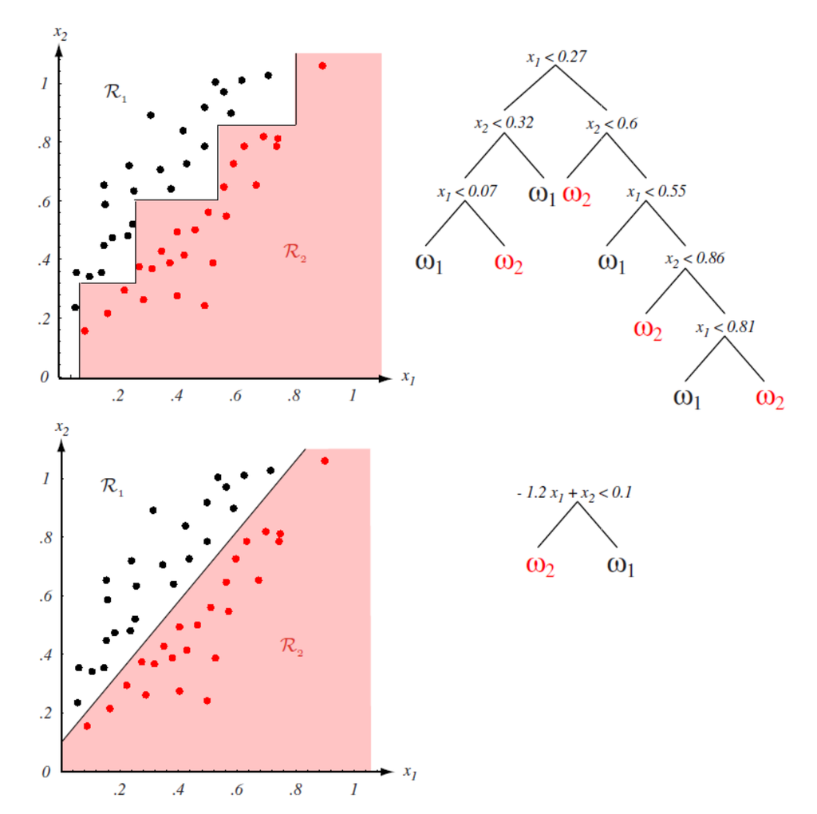

# Solution 2 [5pt]

The top figure shows that depending on the given features, a complicated decision tree may result while it can be better split along another direction. However if PCA is used to find the right direction for data splitting, the decision tree may be simpler as shown below.

# Problem 3 [20pt]

You have 400 photographs. Each photo is 64 $\times$ 64 pixels in size. However, the amount of space left on your computer's hard disk is less than the size of the image dataset. Assume you won't need any high-resolution photographs. Using the knowledge you've gained from the course, describe any approach for reducing the storage of an image dataset.

Hint) You had a similar problem in the homework assignment related to the SVD (`full_matrices = False`).

# Solution 3 [20pt]

- First, make all image into one 2 dimensional array (64$\times$64)$\times$400
- Second, substract average of the array into axis = 0
- Third, make zero centered image, decompose it using SVD (Truncation = 100)
- Finally,the storage is reduced from ((400$\times$4096)$\times$2)-((400$\times$100)+(4096$\times$100))$\times$2

# Problem 4 [25pt]

2) [5pt] Explain how SVD can do low rank approximation.

3) [5pt] Describe the relationship between PCA and SVD

4) [10pt] Prove that minimizing the sum of squared error and maximizing variance are equivalent.

# Solution 4

$$ x^{(i)} = \begin{bmatrix}x_1^{(i)} \\ x_2^{(i)}\\ \vdots \end{bmatrix}, \quad X = \begin{bmatrix} -& (x^{(i)})^T & -\\ - & (x^{(i)})^T & -\\ & \vdots & \\ - & (x^{(m)})^T & -\end{bmatrix}$$

- $m$ observations $\left(x^{(i)}, x^{(2)}, \cdots , x^{(m)}\right)$

$$ \begin{align*} \text{sample mean} \; \bar x &= \frac{x^{(1)} + x^{(2)} + \cdots + x^{(m)}}{m} = \frac{1}{m} \sum\limits_{i=1}^{m}x^{(i)} \\ \text{Sample Variance} : S_x &= \frac{1}{m-1} \sum\limits_{i=1}^{m}\left(x^{(i)}-\bar x\right)^2 \\ \text{Sample Covariance} : S_{xy} &= \frac{1}{m-1} \sum\limits_{i=1}^{m}\left(x^{(i)}-\bar x\right)\left(y^{(i)}-\bar y \right)\\ \text{Sample Covariance matrix} : S &= \begin{bmatrix} S_x & S_{xy} \\ S_{yx} & S_y \end{bmatrix} \end{align*}$$

(2) [5pt]

by SVD,

$$\begin{align*} A = U\Sigma V^T \end{align*}$$

In order to compress $A$ without losing too much information of $A$, we can consider that the large singular values ($\sigma$) has large information of $A$ because the singular value ($\sigma_i$) is the scaling factor corresponding to unit vector $u_i$

$A = U\Sigma V^T$ can be approximated with the large singular values, it is a low rank approximation as the dimension reduction

$$\begin{align*} A = U_r\Sigma_r V_r^T = \sum_{i=1}^r \sigma_iu_iv_i^T \quad \implies \quad \bar{A} = U_k\Sigma_k V_k^T = \sum_{i=1}^k \sigma_iu_iv_i^T \quad (k \le r) \end{align*}$$

(3) [5pt]

Any real symmetric and positive definite matrix $B$ has a eigen decomposition
$$\begin{align*} B = S\Lambda S^T \end{align*}$$
A real matrix $\left(m \times n \right) A$, where $ m > n $, has the decomposition
$$\begin{align*} A = U\Sigma V^T \end{align*}$$
From $A$ (skinny and full rank) we can construct positive-definite symmetric matrices, $A^TA$
$$\begin{align*} A^TA = V\Sigma^T U^TU\Sigma V^T = V\Sigma^T\Sigma V^T \end{align*}$$
PCA by SVD
$$\begin{align*} B = A^TA = V\Sigma^T\Sigma V^T = V \Lambda V^T \end{align*}$$
Note that in PCA,
$$\begin{align*} VSV^T \quad \left(\text{where}\; S = \frac{1}{m} X^TX = \left(\frac{X}{\sqrt{m}} \right)^T \frac{X}{\sqrt{m}} = A^TA \right) \end{align*}$$

(4) [10pt]

\begin{align*} \lVert e^{(i)} \rVert ^2 & = \lVert x^{(i)} \rVert ^2 - \big( {x^{(i)}}^Tu \big)^2 \\ & = \lVert x^{(i)} \rVert ^2 - \big( {x^{(i)}}^Tu \big)^T\big( {x^{(i)}}^Tu \big) \\ & = \lVert x^{(i)} \rVert ^2 - u^Tx^{(i)}{x^{(i)}}^Tu\\ \end{align*}

$$\begin{align*} \frac {1}{m} \sum\limits_{i=1}^{m} \lVert e^{(i)} \rVert ^2 & = \frac {1}{m} \sum\limits_{i=1}^{m} \lVert x^{(i)} \rVert ^2 - \frac{1}{m}\sum\limits_{i=1}^{m}u^Tx^{(i)}{x^{(i)}}^Tu \\ & = \frac {1}{m} \sum\limits_{i=1}^{m} \lVert x^{(i)} \rVert ^2 - u^T\left(\frac{1}{m}\sum\limits_{i=1}^{m}x^{(i)}{x^{(i)}}^T\right)u \end{align*}$$

- Variance of projected data

$$\begin{align*} \text{variance of projected data} & = \frac{1}{m}\sum\limits_{i=1}^{m}\big(u^Tx^{(i)}\big)^2 = \frac{1}{m}\sum\limits_{i=1}^{m}\big( {x^{(i)}}^Tu\big)^2 \\ & = \frac{1}{m}\sum\limits_{i=1}^{m}\big( {x^{(i)}}^Tu\big)^T\big( {x^{(i)}}^Tu\big) = \frac{1}{m}\sum\limits_{i=1}^{m}u^Tx^{(i)}{x^{(i)}}^Tu \\ & = u^T\left(\frac{1}{m}\sum\limits_{i=1}^{m}x^{(i)}{x^{(i)}}^T \right) u \\ \end{align*}$$

- In an optimization form

$$\begin{align*} &\text{minimize} \; \underbrace{\frac {1}{m} \sum\limits_{i=1}^{m} \lVert x^{(i)} \rVert ^2}_{\text{constant given $x_i$}} - \underbrace{u^T\left(\frac{1}{m}\sum\limits_{i=1}^{m}x^{(i)}{x^{(i)}}^T\right)u}_{\text{maximize}} \\ \\ \implies &\text{maximize} \; u^T\left(\frac{1}{m}\sum\limits_{i=1}^{m}x^{(i)}{x^{(i)}}^T\right)u\end{align*}$$

$$ \therefore \; \text{minimize} \; error^2 = \text{maximize} \; variance$$

# Problem 5

The Lagrangian multiplier method is a strategy for finding the local minima or maxima of a function subject to specified constraints. The Lagrangian multiplier method can be summarized as follows:

In order to find the maximum or minimum of a function $f(x)$ subjected to the equality constraint $g(x)=0$, form the Lagrangian function

$$L = f(x)-\lambda g(x)$$

and find the stationary points of $L$ considered as a function of $x$ and the Lagrange multiplier $\lambda$; this means that all partial derivatives should be zero, including the partial derivative with respect to $\lambda$.

PCA can be written as a following optimization form:

$$\begin{align*} \text{maximize} \quad & u^TSu \\ \text{subject to} \quad & u^Tu = 1\end{align*}$$

[10pt] Using the Lagrangian multiplier method, show that eigen-vector $u$ of a sample covariance matrix $S$ is a principal component of PCA.

# Solution 5

[10pt]

$$\begin{align*} L &= u^T S u - \lambda(u^T u -1)\\\\ \frac{\partial L}{\partial u} &= 2 S u-2\lambda u = 0\\\\ S u &= \lambda u \end{align*}$$

# Problem 6 [20pt]

1) [10pt]

We would like to represent the below function with a computational graph

$$f(\omega,x)= \frac{1}{1+e^{- \omega_{0}x_{0}-\omega_{1}x_{1}-\omega_2 }}$$

The green letter is the input of a computational graph and the red box is the gradient's box of a computational graph. Fill the blank of the computational graph.

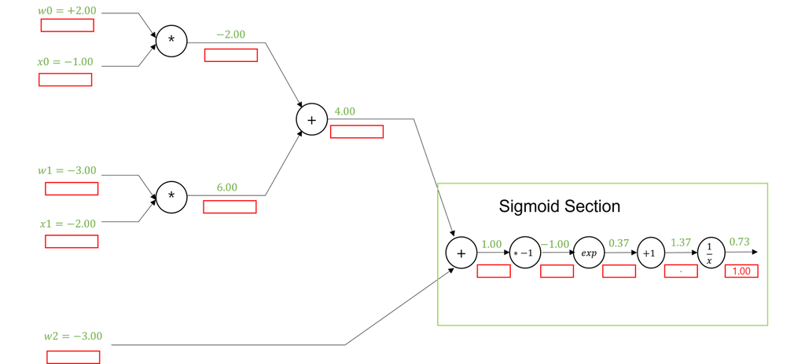

2) [10pt]

The below figure is also a computational graph. However, in this case, the input is not a number but a vector or a matrix. Fill the blank of the computational graph. Here, L2 denotes L2-norm.

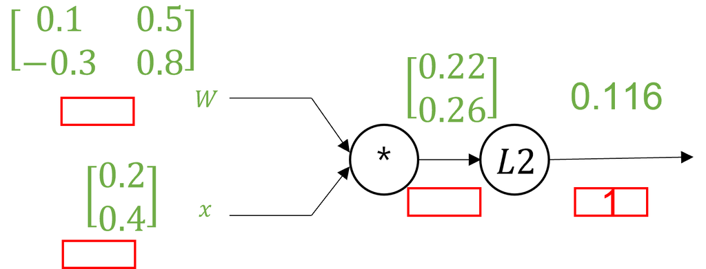

Hint) Use this table if needed.

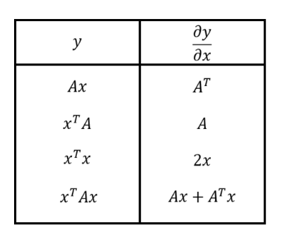

# Solution 6

(a) [10pt]

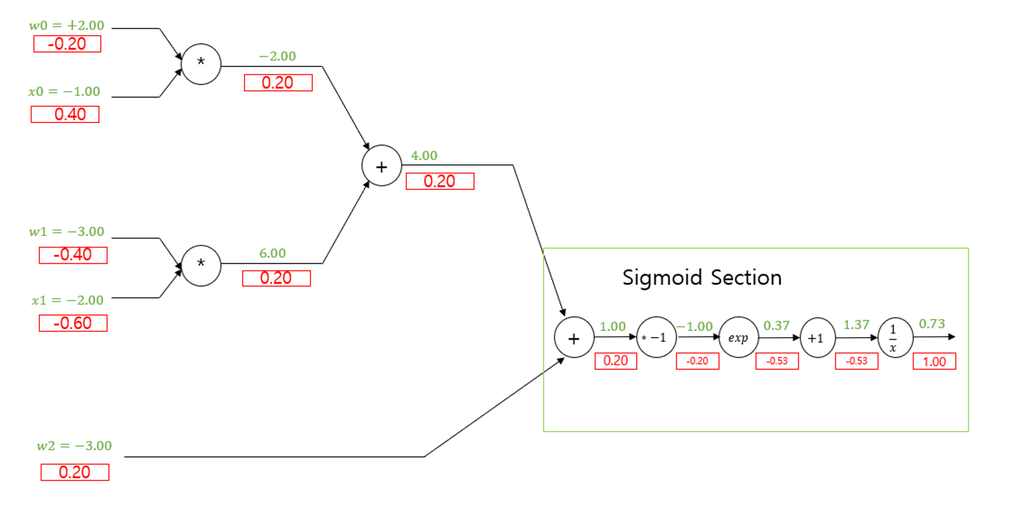

(b) [10pt]

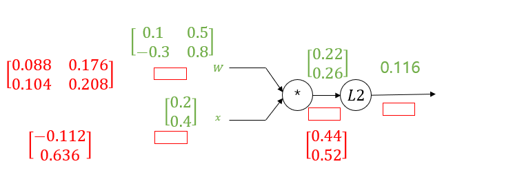